# Introduction

# Confrontation des modèles testés

Nous avons décidé de quantifier la qualité de notre modèle en comparant leur RMSE. Parmi les candidats, nous pouvons citer :

- Naive last : prédiction identique au jour qui précède, répété sur la longueur du test
- LSTM
- Linear : simple combinaisation linéaire des colonnes
- Naive seasonal : prédiction identique à la semaine qui précède.

[figure not shown]

**Conclusion :** Nous allons opter pour le modèle SARIMA.

# Prédiction avec SARIMA

## Présentation du modèle retenu

Le **modèle SARIMA** (autorégressif moyenne mobile intégré saisonnier) est un modèle statistique qui utilise les variations et les régressions des données statistiques pour trouver des modèles pour une prédiction dans le futur. Il s'agit d'un modèle dynamique de séries chronologiques, c'est-à-dire que les estimations futures sont expliquées par des données passées plutôt que par des variables indépendantes.

[figure not shown]

## Chargement et nettoyage des données

```python
df = pd.read_pickle("data/df_train.pkl")
df_ACE = df[df['filename']=='champs-elysees.csv']
df_Sts = df[df['filename']=='convention.csv']
df_convention = df[df['filename']=='sts.csv']

df_test = pd.read_pickle("data/df_test.pkl")
df_ACE_test = df_test[df_test['filename']=='champs-elysees.csv']
df_Sts_test = df_test[df_test['filename']=='convention.csv']
df_convention_test = df_test[df_test['filename']=='sts.csv']


dfs = [df_ACE, df_Sts, df_convention]
dfs_test = [df_ACE_test, df_Sts_test, df_convention_test]
```

## Traitement des dates

```python
# Format d'une série temporelle
for df in dfs:
    df['Date et heure de comptage']= pd.to_datetime(df["Date et heure de comptage"], format='%Y-%m-%d %H:%M:%S')

# for df in dfs_test:
#     df['Date et heure de comptage']= pd.to_datetime(df["Date et heure de comptage"], format='%Y-%m-%d %H:%M:%S')

# Lignes rangées par ordre chronologique
for df in dfs:
    df.sort_values("Date et heure de comptage",inplace = True)

for df in dfs_test:
    df.sort_values("Date et heure de comptage",inplace = True)

def index_and_freq(df):
    df = df.set_index('Date et heure de comptage')
    df = df.asfreq('H', method= 'ffill')
    return df

tagg = ['Champs-Élysées', 'Convention', 'Sts-Pères']

# Nous indiquons que la série temporelle est indexée selon la date
df_ACE = index_and_freq(df_ACE)
df_convention = index_and_freq(df_convention)
df_Sts = index_and_freq(df_Sts)

df_ACE_test = index_and_freq(df_ACE_test)
df_Sts_test = index_and_freq(df_Sts_test)
df_convention_test = index_and_freq(df_convention_test)
```

## Quelques fonctions utilitaires

```python
def create_df(original_df):
    data = pd.DataFrame()
    data['debit'] = original_df['Débit horaire']
    data['taux'] = original_df["Taux d'occupation"]
    data['date'] = original_df.index
    data.sort_values("date",inplace = True)
    data = data.set_index('date')
    data = data.asfreq('H', method= 'ffill')
    return data

def string_to_model(model):
    p = int(model[1])
    q = int(model[4])
    d = int(model[7])
    seasonal = (int(model[10]), int(model[13]), int(model[16]), int(model[19:21]))
    return p,q,d,seasonal
```

```python
def plotting_predictions(X_train, pred, title):
    plt.plot(X_train, label='Données')
    plt.plot(pred, label='Prediction')
    plt.xticks(rotation=45)
    plt.title(title)
    plt.legend()
    plt.show()
```

## Modèles retenus

### GridSearch

Nous avons lancé un GridSearch pour trouver les hyperparamètres optimaux pour le modèle SARIMA. Le calcul ayant pris plus de 24h sur nos machines, nous avons tout simplement noté les résultats du GridSearch dans deux dictionnaires.

Voici les prédictions qui ont été réalisées par les modèles retenus sur la dernière semaine de novembre en utilisant un trainset et un testset :

[figure not shown]

### Résultats

Nous désignerons par les entiers suivants les rues dans les 2 dictionnaires suivants :

```python
modeles_debit = {0: '(4, 1, 5)(4, 1, 4, 24)', 2: '(4, 1, 5)(4, 1, 4, 24)', 1:'(4, 1, 5)(4, 1, 4, 24)'}
modeles_taux = {0: '(1, 0, 1)(2, 1, 1, 24)', 2: '(1, 0, 1)(2, 1, 1, 24)', 1:'(2, 0, 2)(1, 1, 1, 24)'}
```

## Géneration des prédictions

La cellule suivante prend un peu de temps à terminer, mais elle affiche chaque nouveau plot obtenu dès que le calcul correspondant termine. Ceci permet d'avoir rapidement une idée de la qualité de notre modèle.

```
0it [00:00, ?it/s]
```

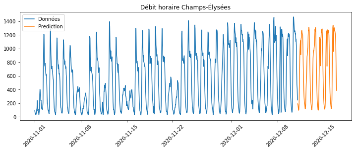

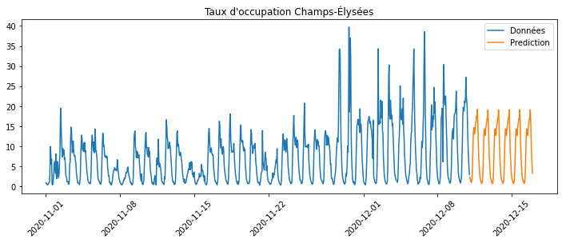

```
1it [30:00, 1800.61s/it]
```

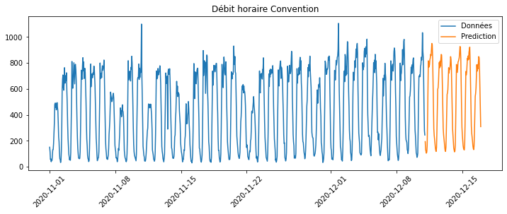

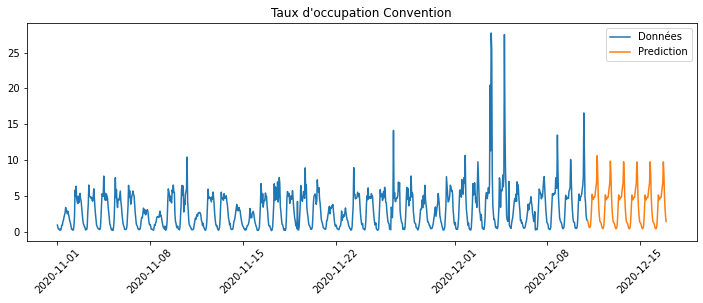

```
2it [1:01:31, 1827.62s/it]
```

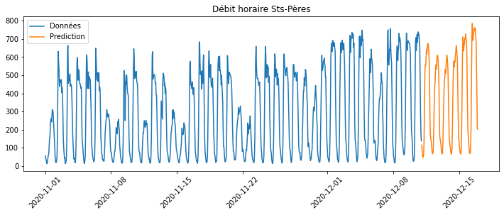

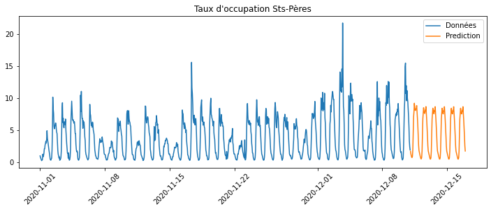

```
3it [1:31:14, 1824.82s/it]
```

```python
df_predictions = pd.DataFrame()

for model_index,df in tqdm(enumerate([df_ACE, df_Sts, df_convention])):

    # Paramètres des modèles
    p_debit,d_debit,q_debit,seasonal_debit = string_to_model(modeles_debit[model_index])
    p_taux,d_taux,q_taux,seasonal_taux = string_to_model(modeles_taux[model_index])

    # Dates de prédiction
    start = datetime.strptime('2020-12-11 01:00:00', '%Y-%m-%d %H:%M:%S')
    end = datetime.strptime('2020-12-16 23:00:00', '%Y-%m-%d %H:%M:%S')

    # Dates de corréction
    start_dec = datetime.strptime('2020-12-09 00:00:00', '%Y-%m-%d %H:%M:%S')
    end_dec = datetime.strptime('2020-12-10 00:00:00', '%Y-%m-%d %H:%M:%S')

    # Création des timeseries pour débit horaire et taux d'occupation
    debit_train_raw = create_df(df).loc['2020-08-01':'2020-12-11 00:00:00'].debit
    taux_train_raw = create_df(df).loc['2020-08-01':'2020-12-11 00:00:00'].taux

    # Correction des données du 9 décembre
    mod_debit_corr = sm.tsa.statespace.SARIMAX(debit_train_raw.loc['2020-11-01':'2020-12-09 00:00:00'],order=(p_debit,d_debit,q_debit),seasonal_order=seasonal_debit,enforce_stationarity=False,enforce_invertibility=False)
    model_debit_corr = mod_debit_corr.fit()
    debit_correc = model_debit_corr.predict(start=start_dec,end=end_dec)

    mod_taux_corr = sm.tsa.statespace.SARIMAX(taux_train_raw.loc['2020-11-01':'2020-12-09 00:00:00'],order=(p_taux,d_taux,q_taux),seasonal_order=seasonal_taux,enforce_stationarity=False,enforce_invertibility=False)
    model_taux_corr = mod_taux_corr.fit()
    taux_correc = model_taux_corr.predict(start=start_dec,end=end_dec)

    # Correction des données:
    debit_train_raw[start_dec : end_dec] = debit_correc
    taux_train_raw[start_dec : end_dec] = taux_correc

    # Ajustement du modèle pour le débit horaire
    mod_debit = sm.tsa.statespace.SARIMAX(debit_train_raw,order=(p_debit,d_debit,q_debit),seasonal_order=seasonal_debit,enforce_stationarity=False,enforce_invertibility=False)
    model_debit = mod_debit.fit()
    debit_pred = model_debit.predict(start=start,end=end)

    # Ajustement du modèle pour le taux d'occupation
    mod_taux = sm.tsa.statespace.SARIMAX(taux_train_raw,order=(p_taux,d_taux,q_taux),seasonal_order=seasonal_taux,enforce_stationarity=False,enforce_invertibility=False)
    model_taux = mod_taux.fit()
    taux_pred = model_taux.predict(start=start,end=end)

    # Rajout des données au DataFrame
    temp_df = pd.DataFrame()
    temp_df['Datetime'] = taux_pred.index
    temp_df['Arc'] = [tagg[model_index] for i in range(len(taux_pred))]
    temp_df["Débit horaire"] = debit_pred.values
    temp_df["Taux d'occupation"] = taux_pred.values

    # Rajout des données de minuit (une ligne)
    first_hour = pd.DataFrame()
    first_hour['Datetime'] = [taux_train.index[-1]]
    first_hour['Arc'] = [tagg[model_index]]
    first_hour["Taux d'occupation"] = [taux_train.values[-1]]
    first_hour["Débit horaire"] = [debit_train.values[-1]]

    temp_df = temp_df.append(first_hour)
    temp_df.sort_values("Datetime",inplace = True)
    df_predictions = pd.concat([df_predictions, temp_df])

    rcParams['figure.figsize'] = 12, 4
    plotting_predictions(debit_train_raw.loc['2020-11-01':'2020-12-11 00:00:00'], debit_pred, "Débit horaire " + tagg[model_index])
    plotting_predictions(taux_train_raw.loc['2020-11-01':'2020-12-11 00:00:00'], taux_pred, "Taux d'occupation " + tagg[model_index])
```

## Export des prédictions

Les données ayant déjà mises en forme conformément à ce qui a été demandé dans les consignes du challenge, il ne nous reste plus qu'à les exporter dans un fichier `output.csv`.

```python
df_predictions.to_csv('output.csv', index=False)
```

```python
df_predictions.head()
```

|  | Datetime | Arc | Débit horaire | Taux d'occupation |
| --- | --- | --- | --- | --- |
| 0 | 2020-12-11 00:00:00 | Champs-Élysées | 247.000000 | 2.981110 |
| 0 | 2020-12-11 01:00:00 | Champs-Élysées | 175.105746 | 2.349191 |
| 1 | 2020-12-11 02:00:00 | Champs-Élysées | 129.010708 | 1.785235 |
| 2 | 2020-12-11 03:00:00 | Champs-Élysées | 68.825435 | 1.345536 |
| 3 | 2020-12-11 04:00:00 | Champs-Élysées | 22.530303 | 1.054927 |

# Conclusion

Pendant ce Datathon, nous avons eu l’opportunité de nous confronter à un problème complexe nous permettant de développer des compétences en Data Science (notamment pour le traitement des séries temporelles) et en réalisation de projet. Nous sommes d’ailleurs convaincus que le travail élaboré n’est qu’une étape primaire aussi bien pour une carrière professionnelle que pour des études plus approfondies.

À l’issue de ce travail, nous aimerions exprimer notre reconnaissance à CentraleSupélec et à BCG Gamma et plus particulièrement aux organisateurs du Datathon.

Cordialement,  
L'équipe *Delivery CS*